# Part II - Prosper Loan Data Exploratory Analysis Presentation

## by Victor Oguche

## Investigation Overview

This Exploratory and Explanatory analysis was carried out with the aim of finding trends, patterns and insight into the features that should be considered before issueing a loan based off the prosper loan dataset.

## Dataset Overview

The Prosper Loan dataset is a collection of loan records. Using the Prosper Loan dataset, Exploratory and Explanatory analysis was be carried out with the aim of finding trends, patterns and insight from the loan dataset. The Dataset contain 113937 row entries and 81 Columns.

## Loan Original Amount Distribution

The loan original amount is the origination amount of the loan. The transformed logarithmic scale plot shows a bimodal distribution with peak frequency about the 5k and 10k loan amount respectively. The scale chart shows that a large amount of the loan original amount falls in the middle range. While a very few number of the loan records has high loan original amount.

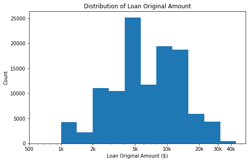

## Distribution of Stated Monthly Income

The monthly income the borrower stated at the time the listing was created. On the transformed scale, the Stated Monthly Income has a normal distribution which was expected due to general income distribution pattern where less number of individuals are expected at the peak and low point with high count around the average region.

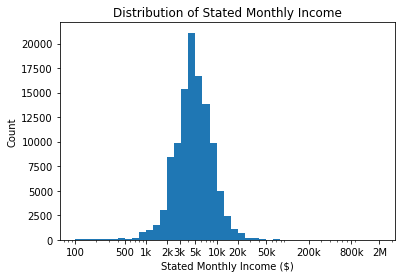

## Listing category distribution

The Listing category is the category of the listing that the borrower selected when posting their listing. Majority of the loans where given for Debt Consolidation. Borrowers were taking the loan to pay off other loans.

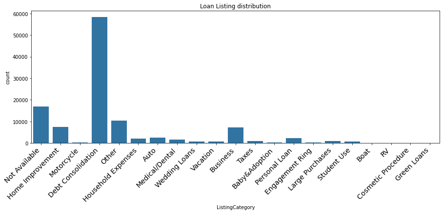

## Loan Original Amount and Monthly Loan Payment distribution in respect to Employment Status

There is an interesting pattern in regards to the loan original amount and the monthly loan payment for a borrower based on their employment status. There are more higher loan amount given to employeed borrower. The monthly loan payment amount is almost same for self-employed and employed borrowers but the mean is higher for employed showing possible reason for the higher loan amount given to employed borrowers.

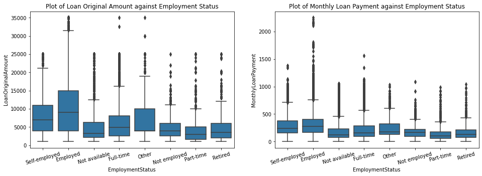

## Borrower APR across Prosper rating and Income Range

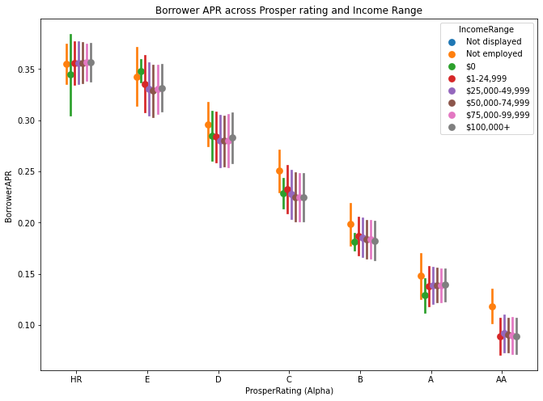